# PDC Report

Data downloaded from PDC portal on August 9, 2021. All fields checked against PDC Data Dictionary.

Note for all PDC Data: “null” used as a value but is never a recorded option in data dictionary when there are also blank cells.

## Biospecimen

### Aliquots:

#### **analyte_type**

Table 1.1: Analyte Type Value Distribution

| Analyte Type | Frequency |
| --- | --- |
| null | 3816 |

Note that there is an analyte_type field in both Aliquots and Analytes but only one field in the data table, “Analyte Type”, which is not an exact match with the field name.

10 permissible values, all unused.

#### **analyte_type_id**

No exact or similar fields found within biospecimen manifest for this field.

#### **pool**

No exact or similar fields found within biospecimen manifest for this field.

#### **status**

Table 1.2: Aliquot Status Value Distribution

| Aliquot Status | Frequency |
| --- | --- |
| Disqualified | 64 |
| null | 6 |
| Qualified | 3746 |

In the data table field name is “Aliquot Status” which is not an exact match to data dictionary entry “status”.

2 permissible values, all used.

#### **aliquot_is_ref**

Table 1.3: Aliquot Is Ref Value Distribution

| Aliquot is Ref | Frequency |
| --- | --- |
| no | 3756 |
| yes | 60 |

Field name is “Aliquot Is Ref” in data table, not exact match to data dictionary entry “aliquot_is_ref”.

2 permissible values, all used.

### Analyte

Only 1 analyte type field found reported above. No analtye_type_id found.

#### **normal_tumor_genotype_snp_match**

No exact or similar fields found within biospecimen manifest for this field.

### Sample

##### **sample_type**

Table 1.4: Sample Type Value Distribution

| Sample Type | Frequency |
| --- | --- |
| Cell Lines | 119 |
| Normal | 12 |
| Normal Adjacent Tissue | 108 |
| Not Reported | 70 |
| Primary Tumor | 2122 |
| Solid Tissue Normal | 1022 |
| Tumor | 237 |
| Xenograft Tissue | 126 |

Field name is “Sample Type” in data table, not exact match to data dictionary entry “sample_type”.

##### Unused Values:

*Additional Metastatic*, *Additional - New Primary*, *Benign Neoplasms*, *Blood Derived Cancer - Bone Marrow*, *Blood Derived Cancer - Bone Marrow, Post-treatment*, *Blood Derived Cancer - Peripheral Blood*, *Blood Derived Cancer - Peripheral Blood, Post-treatment*, *Blood Derived Liquid Biopsy*, *Blood Derived Normal*, *Bone Marrow Normal*, *Buccal Cell Normal*, *Cell Line Derived Xenograft Tissue*, *Control Analyte*, *DNA*, *EBV Immortalized Normal*, *Expanded Next Generation Cancer Model*, *FFPE Recurrent*, *FFPE Scrolls*, *Fibroblasts from Bone Marrow Normal*, *GenomePlex (Rubicon) Amplified DNA*, *Granulocytes*, *Human Tumor Original Cells*, *In Situ Neoplasms*, *Lymphoid Normal*, *Metastatic*, *Mononuclear Cells from Bone Marrow Normal*, *Neoplasms of Uncertain and Unknown Behavior*, *Next Generation Cancer Model*, *Primary Blood Derived Cancer - Peripheral Blood*, *Recurrent Blood Derived Cancer - Peripheral Blood*, *Pleural Effusion*, *Primary Blood Derived Cancer - Bone Marrow*, *Primary Xenograft Tissue*, *Post neo-adjuvant therapy*, *Recurrent Blood Derived Cancer - Bone Marrow*, *Recurrent Tumor*, *Repli-G (Qiagen) DNA*, *Repli-G X (Qiagen) DNA*, *RNA*, *Slides*, *Total RNA*, *Tumor Adjacent Normal - Post Neo-adjuvant Therapy*, *Unknown* and *Not Allowed To Collect*

#### **tissue_type**

Table 1.5: Tissue Type Value Distribution

| Tissue Type | Frequency |
| --- | --- |
| null | 3816 |

Field name is “Tissue Type” in data table, not exact match to data dictionary entry “tissue_type”.

7 permissible values, all unused.

Table 1.6: Biospecimen Anatomic Site Value Distribution

| Biospecimen Anatomic Site | Frequency |
| --- | --- |
| null | 3816 |

Field name is “Biospecimen Anatomic Site” in data table, not exact match to data dictionary entry “biospecimen_anatomic_site”.

285 permissible values, all unused.

#### **biospecimen_laterality**

No exact or similar fields found within biospecimen manifest for this field.

#### **composition**

Table 1.7: Composition Value Distribution

| Composition | Frequency |
| --- | --- |
| null | 3816 |

Field name is “Composition” in data table, not exact match to data dictionary entry “composition”.

33 permissible values, all unused.

#### **diagnosis_pathologically_confirmed**

Table 1.8: Diagnosis Pathologically Confirmed Value Distribution

| Diagnosis Pathoogically Confirmed | Frequency |
| --- | --- |
| null | 3816 |

Field name is “Diagnosis Pathologically Confirmed” in data table, not exact match to data dictionary entry “diagnosis_pathologically_confirmed”.

5 permissible values, all unused.

#### **distance_normal_to_tumor**

No exact or similar fields found within biospecimen manifest for this field.

#### **is_ffpe**

Table 1.9: Is FFPE Value Distribution

| Is FFPE | Frequency |
| --- | --- |
| null | 3816 |

Field name is “Is FFPE” in data table, not exact match to data dictionary entry “is_ffpe”.

2 values total, both unused.

#### **method_of_sample_procurement**

Table 1.10: Method of Sample Procurement Value Distribution

| Method Of Sample Procurement | Frequency |
| --- | --- |
| null | 3816 |

Field name is “Method of Sample Procurement” in data table, not exact match to data dictionary entry “method_sample_procurement”.

77 permissible values, all unused.

#### **preservation_method**

Table 1.11: Preservation Method Value Distribution

| Preservation Method | Frequency |
| --- | --- |
| null | 3816 |

Field name is “Preservation Method” in data table, not exact match to data dictionary entry “preservation_method”.

9 permissible values, all unused.

#### **sample_type_id**

Table 1.12: Sample Type ID Value Distribution

| Sample Type ID | Frequency |
| --- | --- |
| null | 3816 |

Field name is “Sample Type ID” in data table, not exact match to data dictionary entry “sample_type_id”.

31 permissible values, all unused.

#### **tumor_code**

Table 1.13: Tumor Code Value Distribution

| Tumor Code | Frequency |
| --- | --- |
| null | 3816 |

Field name is “Tumor Code” in data table, not exact match to data dictionary entry “tumor_code”.

25 permissible values, all unused.

#### **tumor_code_id**

Table 1.14: Tumor Code ID Value Distribution

| Tumor Code ID | Frequency |
| --- | --- |
| null | 3816 |

Field name is “Tumor Code ID” in data table, not exact match to data dictionary entry “tumor_code_id”.

25 permissible values, all unused.

#### **tumor_descriptor**

Table 1.15: Tumor Descriptor Value Distribution

| Tumor Descriptor | Frequency |
| --- | --- |
| null | 3816 |

Field name is “Tumor Descriptor” in data table, not exact match to data dictionary entry “tumor_descriptor”.

9 permissible values, all unused.

#### **pool**

No exact or similar fields found within biospecimen manifest for this field.

#### **sample_is_ref**

Table 1.16: Sample Is Ref Value Distribution

| Sample Is Ref | Frequency |
| --- | --- |
| null | 3816 |

Field name is “Sample Is Ref” in data table, not exact match to data dictionary entry “sample_is_ref”.

2 permissible values, both unused.

## Clinical

### Demographic

#### **ethnicity**

Table 2.1: Ethnicity Value Distribution

| Ethnicity | Frequency |
| --- | --- |
| Hispanic or Latino | 53 |
| Not Hispanic or Latino | 870 |
| Not Reported | 1424 |

Field name is “Ethnicity” in data table, not exact match to data dictionary entry “ethnicity”.

Note that the values used in the data table are capitalized when this is not the case in the data dictionary.

##### Unused Values:

6 permissible values, 3 unused. *not allowed to collect* unknown *Unknown

#### **gender**

Table 2.2: Gender Value Distribution

| Gender | Frequency |
| --- | --- |
| Female | 1172 |
| Male | 941 |
| Not Reported | 230 |
| Unspecified | 4 |

Field name is “Gender” in data table, not exact match to data dictionary entry “gender”.

Same note about capitalization above applies here.

##### Unused Values:

5 permissible values, 1 unused. * unknown

#### **race**

Table 2.3: Race Value Distribution

| Race | Frequency |
| --- | --- |
| American Indian or Alaska Native | 9 |
| Asian | 75 |
| Black or African American | 76 |
| Chinese | 160 |
| Native Hawaiian or Other Pacific Islander | 1 |
| Not Reported | 1148 |
| Unknown | 3 |
| White | 875 |

Field name is “Race” in data table, not exact match to data dictionary entry “race”.

Same note about capitalization above applies here.

##### Unused Values:

10 values listed in data dictionary, 3 unused listed below: “Chinese” added as field value, but not reported in data dictionary. * unknown * not allowed to collect * other

#### **cause_of_death**

Table 2.4: Cause of Death Value Distribution

| Cause of Death | Frequency |
| --- | --- |
| Cancer cell proliferation | 1 |
| Cancer Related | 31 |
| Cardiovascular Disorder, NOS | 2 |
| Cerebral Hemorrhage | 1 |
| HCC recurrence | 7 |
| Infection | 3 |
| Metastasis | 2 |
| Not Cancer Related | 12 |
| Not Reported | 900 |
| null | 1379 |
| Surgical Complications | 1 |
| Unknown | 8 |

Field name is “Cause of Death” in data table, not exact match to data dictionary entry “cause_of_death”.

##### Unused Values:

11 values listed in data dictionary, 4 unused listed below:

- End-stage Renal Disease
- Renal Disorder, NOS
- Spinal Muscular Atrophy
- Toxicity

Values in data table but not listed in data dictionary: * Cancer cell proliferation * Cerebral Hemorrhage * HCC recurrence * Metastasis

#### **premature_at_birth**

No exact or similar fields found within clinical manifest for this field.

#### **vital_status**

Table 2.5: Vital Status Value Distribution

| Vital status | Frequency |
| --- | --- |
|  | 16 |
| alive | 1 |
| Alive | 1058 |
| Dead | 454 |
| Not Reported | 500 |
| null | 318 |

Field name is “Vital Status” in data table, not exact match to data dictionary entry “vital_status”.

##### Unused Values:

4 permissible values, 1 unused * Unknown

Values in data table not listed in data dictionary: *alive

#### **cause_of_death_source**

No exact or similar fields found within clinical manifest for cause_of_death_source field.

### Diagnosis

#### **last_known_disease_status**

Table 2.6: Last Known Disease Status Value Distribution

| Last Known Disease Status | Frequency |
| --- | --- |
| Not Reported | 1371 |
| Tumor free | 243 |
| Tumor Free | 234 |
| Unknown tumor status | 169 |
| Unknown Tumor Status | 58 |
| With tumor | 156 |
| With Tumor | 116 |

Field name is “Last Known Disease Status” in data table, not exact match to data dictionary entry “last_known_disease_status”.

##### Unused Values

Values in data table not listed in data dictionary or not exact matches: * Tumor Free * Unknown Tumor Status * With Tumor

#### **morphology**

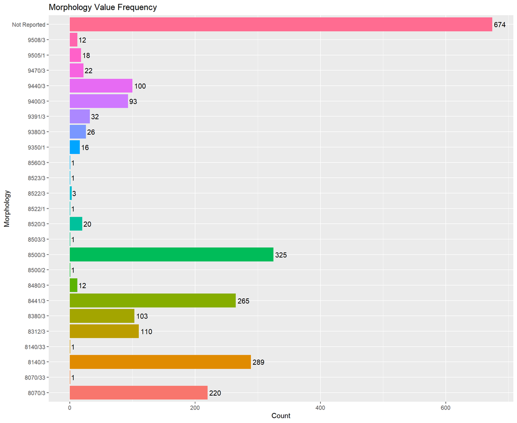

Field name is “Morphology” in data table, not exact match to data dictionary entry “morphology”.

##### Unused Values:

1127 permissible values, 1102 unused values listed below.

*8000/0*, *8000/1*, *8000/3*, *8000/6*, *8000/9*, *8001/0*, *8001/1*, *8001/3*, *8002/3*, *8003/3*, *8004/3*, *8005/0*, *8005/3*, *8010/0*, *8010/2*, *8010/3*, *8010/6*, *8010/9*, *8011/0*, *8011/3*, *8012/3*, *8013/3*, *8014/3*, *8015/3*, *8020/3*, *8021/3*, *8022/3*, *8023/3*, *8030/3*, *8031/3*, *8032/3*, *8033/3*, *8034/3*, *8035/3*, *8040/0*, *8040/1*, *8041/3*, *8041/34*, *8042/3*, *8043/3*, *8044/3*, *8045/3*, *8046/3*, *8050/0*, *8050/2*, *8050/3*, *8051/0*, *8051/3*, *8052/0*, *8052/2*, *8052/3*, *8053/0*, *8060/0*, *8070/2*, *8070/6*, *8071/2*, *8071/3*, *8072/3*, *8073/3*, *8074/3*, *8075/3*, *8076/2*, *8076/3*, *8077/0*, *8077/2*, *8078/3*, *8080/2*, *8081/2*, *8082/3*, *8083/3*, *8084/3*, *8085/3*, *8086/3*, *8090/1*, *8090/3*, *8091/3*, *8092/3*, *8093/3*, *8094/3*, *8095/3*, *8096/0*, *8097/3*, *8098/3*, *8100/0*, *8101/0*, *8102/0*, *8102/3*, *8103/0*, *8110/0*, *8110/3*, *8120/0*, *8120/1*, *8120/2*, *8120/3*, *8121/0*, *8121/1*, *8121/3*, *8122/3*, *8123/3*, *8124/3*, *8130/1*, *8130/2*, *8130/3*, *8131/3*, *8140/0*, *8140/1*, *8140/2*, *8140/6*, *8141/3*, *8142/3*, *8143/3*, *8144/3*, *8145/3*, *8146/0*, *8147/0*, *8147/3*, *8148/0*, *8148/2*, *8149/0*, *8150/0*, *8150/1*, *8150/3*, *8151/0*, *8151/3*, *8152/1*, *8152/3*, *8153/1*, *8153/3*, *8154/3*, *8155/1*, *8155/3*, *8156/1*, *8156/3*, *8158/1*, *8160/0*, *8160/3*, *8161/0*, *8161/3*, *8162/3*, *8163/0*, *8163/2*, *8163/3*, *8170/0*, *8170/3*, *8171/3*, *8172/3*, *8173/3*, *8174/3*, *8175/3*, *8180/3*, *8190/0*, *8190/3*, *8191/0*, *8200/0*, *8200/3*, *8201/2*, *8201/3*, *8202/0*, *8204/0*, *8210/0*, *8210/2*, *8210/3*, *8211/0*, *8211/3*, *8212/0*, *8213/0*, *8213/3*, *8214/3*, *8215/3*, *8220/0*, *8220/3*, *8221/0*, *8221/3*, *8230/2*, *8230/3*, *8231/3*, *8240/1*, *8240/3*, *8241/3*, *8242/1*, *8242/3*, *8243/3*, *8244/3*, *8245/1*, *8245/3*, *8246/3*, *8247/3*, *8248/1*, *8249/3*, *8250/1*, *8250/2*, *8250/3*, *8251/0*, *8251/3*, *8252/3*, *8253/3*, *8254/3*, *8255/3*, *8256/3*, *8257/3*, *8260/0*, *8260/3*, *8261/0*, *8261/2*, *8261/3*, *8262/3*, *8263/0*, *8263/2*, *8263/3*, *8264/0*, *8265/3*, *8270/0*, *8270/3*, *8271/0*, *8272/0*, *8272/3*, *8280/0*, *8280/3*, *8281/0*, *8281/3*, *8290/0*, *8290/3*, *8300/0*, *8300/3*, *8310/0*, *8310/3*, *8311/1*, *8311/3*, *8313/0*, *8313/1*, *8313/3*, *8314/3*, *8315/3*, *8316/3*, *8317/3*, *8318/3*, *8319/3*, *8320/3*, *8321/0*, *8322/0*, *8322/3*, *8323/0*, *8323/3*, *8324/0*, *8325/0*, *8330/0*, *8330/1*, *8330/3*, *8331/3*, *8332/3*, *8333/0*, *8333/3*, *8334/0*, *8335/3*, *8336/0*, *8337/3*, *8339/3*, *8340/3*, *8341/3*, *8342/3*, *8343/2*, *8343/3*, *8344/3*, *8345/3*, *8346/3*, *8347/3*, *8350/3*, *8360/1*, *8361/0*, *8370/0*, *8370/1*, *8370/3*, *8371/0*, *8372/0*, *8373/0*, *8374/0*, *8375/0*, *8380/0*, *8380/1*, *8380/2*, *8381/0*, *8381/1*, *8381/3*, *8382/3*, *8383/3*, *8384/3*, *8390/0*, *8390/3*, *8391/0*, *8392/0*, *8400/0*, *8400/1*, *8400/3*, *8401/0*, *8401/3*, *8402/0*, *8402/3*, *8403/0*, *8403/3*, *8404/0*, *8405/0*, *8406/0*, *8407/0*, *8407/3*, *8408/0*, *8408/1*, *8408/3*, *8409/0*, *8409/3*, *8410/0*, *8410/3*, *8413/3*, *8420/0*, *8420/3*, *8430/1*, *8430/3*, *8440/0*, *8440/3*, *8441/0*, *8441/2*, *8442/1*, *8443/0*, *8444/1*, *8450/0*, *8450/3*, *8451/1*, *8452/1*, *8452/3*, *8453/0*, *8453/2*, *8453/3*, *8454/0*, *8460/0*, *8460/2*, *8460/3*, *8461/0*, *8461/3*, *8462/1*, *8463/1*, *8470/0*, *8470/2*, *8470/3*, *8471/0*, *8471/3*, *8472/1*, *8473/1*, *8474/1*, *8474/3*, *8480/0*, *8480/1*, *8480/6*, *8481/3*, *8482/3*, *8490/3*, *8490/6*, *8501/2*, *8501/3*, *8502/3*, *8503/0*, *8503/2*, *8504/0*, *8504/2*, *8504/3*, *8505/0*, *8506/0*, *8507/2*, *8507/3*, *8508/3*, *8509/2*, *8509/3*, *8510/3*, *8512/3*, *8513/3*, *8514/3*, *8519/2*, *8520/2*, *8521/1*, *8521/3*, *8522/2*, *8524/3*, *8525/3*, *8530/3*, *8540/3*, *8541/3*, *8542/3*, *8543/3*, *8550/0*, *8550/1*, *8550/3*, *8551/3*, *8552/3*, *8560/0*, *8561/0*, *8562/3*, *8570/3*, *8571/3*, *8572/3*, *8573/3*, *8574/3*, *8575/3*, *8576/3*, *8580/0*, *8580/1*, *8580/3*, *8581/1*, *8581/3*, *8582/1*, *8582/3*, *8583/1*, *8583/3*, *8584/1*, *8584/3*, *8585/1*, *8585/3*, *8586/3*, *8587/0*, *8588/3*, *8589/3*, *8590/1*, *8591/1*, *8592/1*, *8593/1*, *8594/1*, *8600/0*, *8600/3*, *8601/0*, *8602/0*, *8610/0*, *8620/1*, *8620/3*, *8621/1*, *8622/1*, *8623/1*, *8630/0*, *8630/1*, *8630/3*, *8631/0*, *8631/1*, *8631/3*, *8632/1*, *8633/1*, *8634/1*, *8634/3*, *8640/1*, *8640/3*, *8641/0*, *8642/1*, *8650/0*, *8650/1*, *8650/3*, *8660/0*, *8670/0*, *8670/3*, *8671/0*, *8680/0*, *8680/1*, *8680/3*, *8681/1*, *8682/1*, *8683/0*, *8690/1*, *8691/1*, *8692/1*, *8693/1*, *8693/3*, *8700/0*, *8700/3*, *8710/3*, *8711/0*, *8711/3*, *8712/0*, *8713/0*, *8714/3*, *8720/0*, *8720/2*, *8720/3*, *8721/3*, *8722/0*, *8722/3*, *8723/0*, *8723/3*, *8725/0*, *8726/0*, *8727/0*, *8728/0*, *8728/1*, *8728/3*, *8730/0*, *8730/3*, *8740/0*, *8740/3*, *8741/2*, *8741/3*, *8742/2*, *8742/3*, *8743/3*, *8744/3*, *8745/3*, *8746/3*, *8750/0*, *8760/0*, *8761/0*, *8761/1*, *8761/3*, *8762/1*, *8770/0*, *8770/3*, *8771/0*, *8771/3*, *8772/0*, *8772/3*, *8773/3*, *8774/3*, *8780/0*, *8780/3*, *8790/0*, *8800/0*, *8800/3*, *8800/9*, *8801/3*, *8802/3*, *8803/3*, *8804/3*, *8805/3*, *8806/3*, *8810/0*, *8810/1*, *8810/3*, *8811/0*, *8811/1*, *8811/3*, *8812/0*, *8812/3*, *8813/0*, *8813/3*, *8814/3*, *8815/0*, *8815/1*, *8815/3*, *8820/0*, *8821/1*, *8822/1*, *8823/0*, *8824/0*, *8824/1*, *8825/0*, *8825/1*, *8825/3*, *8826/0*, *8827/1*, *8830/0*, *8830/1*, *8830/3*, *8831/0*, *8832/0*, *8832/3*, *8833/3*, *8834/1*, *8835/1*, *8836/1*, *8840/0*, *8840/3*, *8841/1*, *8842/0*, *8842/3*, *8850/0*, *8850/1*, *8850/3*, *8851/0*, *8851/3*, *8852/0*, *8852/3*, *8853/3*, *8854/0*, *8854/3*, *8855/3*, *8856/0*, *8857/0*, *8857/3*, *8858/3*, *8860/0*, *8861/0*, *8862/0*, *8870/0*, *8880/0*, *8881/0*, *8890/0*, *8890/1*, *8890/3*, *8891/0*, *8891/3*, *8892/0*, *8893/0*, *8894/0*, *8894/3*, *8895/0*, *8895/3*, *8896/3*, *8897/1*, *8898/1*, *8900/0*, *8900/3*, *8901/3*, *8902/3*, *8903/0*, *8904/0*, *8905/0*, *8910/3*, *8912/3*, *8920/3*, *8921/3*, *8930/0*, *8930/3*, *8931/3*, *8932/0*, *8933/3*, *8934/3*, *8935/0*, *8935/1*, *8935/3*, *8936/0*, *8936/1*, *8936/3*, *8940/0*, *8940/3*, *8941/3*, *8950/3*, *8951/3*, *8959/0*, *8959/1*, *8959/3*, *8960/1*, *8960/3*, *8963/3*, *8964/3*, *8965/0*, *8966/0*, *8967/0*, *8970/3*, *8971/3*, *8972/3*, *8973/3*, *8974/1*, *8975/1*, *8980/3*, *8981/3*, *8982/0*, *8982/3*, *8983/0*, *8983/3*, *8990/0*, *8990/1*, *8990/3*, *8991/3*, *9000/0*, *9000/1*, *9000/3*, *9010/0*, *9011/0*, *9012/0*, *9013/0*, *9014/0*, *9014/1*, *9014/3*, *9015/0*, *9015/1*, *9015/3*, *9016/0*, *9020/0*, *9020/1*, *9020/3*, *9030/0*, *9040/0*, *9040/3*, *9041/3*, *9042/3*, *9043/3*, *9044/3*, *9045/3*, *9050/0*, *9050/3*, *9051/0*, *9051/3*, *9052/0*, *9052/3*, *9053/3*, *9054/0*, *9055/0*, *9055/1*, *9060/3*, *9061/3*, *9062/3*, *9063/3*, *9064/2*, *9064/3*, *9065/3*, *9070/3*, *9071/3*, *9072/3*, *9073/1*, *9080/0*, *9080/1*, *9080/3*, *9081/3*, *9082/3*, *9083/3*, *9084/0*, *9084/3*, *9085/3*, *9086/3*, *9090/0*, *9090/3*, *9091/1*, *9100/0*, *9100/1*, *9100/3*, *9101/3*, *9102/3*, *9103/0*, *9104/1*, *9105/3*, *9110/0*, *9110/1*, *9110/3*, *9120/0*, *9120/3*, *9121/0*, *9122/0*, *9123/0*, *9124/3*, *9125/0*, *9130/0*, *9130/1*, *9130/3*, *9131/0*, *9132/0*, *9133/1*, *9133/3*, *9135/1*, *9136/1*, *9137/3*, *9140/3*, *9141/0*, *9142/0*, *9150/0*, *9150/1*, *9150/3*, *9160/0*, *9161/0*, *9161/1*, *9170/0*, *9170/3*, *9171/0*, *9172/0*, *9173/0*, *9174/0*, *9174/1*, *9175/0*, *9180/0*, *9180/3*, *9181/3*, *9182/3*, *9183/3*, *9184/3*, *9185/3*, *9186/3*, *9187/3*, *9191/0*, *9192/3*, *9193/3*, *9194/3*, *9195/3*, *9200/0*, *9200/1*, *9210/0*, *9210/1*, *9220/0*, *9220/1*, *9220/3*, *9221/0*, *9221/3*, *9230/0*, *9230/3*, *9231/3*, *9240/3*, *9241/0*, *9242/3*, *9243/3*, *9250/1*, *9250/3*, *9251/1*, *9251/3*, *9252/0*, *9252/3*, *9260/3*, *9261/3*, *9262/0*, *9270/0*, *9270/1*, *9270/3*, *9271/0*, *9272/0*, *9273/0*, *9274/0*, *9275/0*, *9280/0*, *9281/0*, *9282/0*, *9290/0*, *9290/3*, *9300/0*, *9301/0*, *9302/0*, *9302/3*, *9310/0*, *9310/3*, *9311/0*, *9312/0*, *9320/0*, *9321/0*, *9322/0*, *9330/0*, *9330/3*, *9340/0*, *9341/1*, *9341/3*, *9342/3*, *9351/1*, *9352/1*, *9360/1*, *9361/1*, *9362/3*, *9363/0*, *9364/3*, *9365/3*, *9370/3*, *9371/3*, *9372/3*, *9373/0*, *9381/3*, *9382/3*, *9383/1*, *9384/1*, *9385/3*, *9390/0*, *9390/1*, *9390/3*, *9392/3*, *9393/3*, *9394/1*, *9395/3*, *9396/3*, *9401/3*, *9410/3*, *9411/3*, *9412/1*, *9413/0*, *9420/3*, *9421/1*, *9423/3*, *9424/3*, *9425/3*, *9430/3*, *9431/1*, *9432/1*, *9441/3*, *9442/1*, *9442/3*, *9444/1*, *9445/3*, *9450/3*, *9451/3*, *9460/3*, *9471/3*, *9472/3*, *9473/3*, *9474/3*, *9475/3*, *9476/3*, *9477/3*, *9478/3*, *9480/3*, *9490/0*, *9490/3*, *9491/0*, *9492/0*, *9493/0*, *9500/3*, *9501/0*, *9501/3*, *9502/0*, *9502/3*, *9503/3*, *9504/3*, *9505/3*, *9506/1*, *9507/0*, *9509/1*, *9510/0*, *9510/3*, *9511/3*, *9512/3*, *9513/3*, *9514/1*, *9520/3*, *9521/3*, *9522/3*, *9523/3*, *9530/0*, *9530/1*, *9530/3*, *9531/0*, *9532/0*, *9533/0*, *9534/0*, *9535/0*, *9537/0*, *9538/1*, *9538/3*, *9539/1*, *9539/3*, *9540/0*, *9540/1*, *9540/3*, *9541/0*, *9542/3*, *9550/0*, *9560/0*, *9560/1*, *9560/3*, *9561/3*, *9562/0*, *9570/0*, *9571/0*, *9571/3*, *9580/0*, *9580/3*, *9581/3*, *9582/0*, *9590/3*, *9591/3*, *9596/3*, *9597/3*, *9650/3*, *9651/3*, *9652/3*, *9653/3*, *9654/3*, *9655/3*, *9659/3*, *9661/3*, *9662/3*, *9663/3*, *9664/3*, *9665/3*, *9667/3*, *9670/3*, *9671/3*, *9673/3*, *9675/3*, *9678/3*, *9679/3*, *9680/3*, *9684/3*, *9687/3*, *9688/3*, *9689/3*, *9690/3*, *9691/3*, *9695/3*, *9698/3*, *9699/3*, *9700/3*, *9701/3*, *9702/3*, *9705/3*, *9708/3*, *9709/3*, *9712/3*, *9714/3*, *9716/3*, *9717/3*, *9718/3*, *9719/3*, *9724/3*, *9725/3*, *9726/3*, *9727/3*, *9728/3*, *9729/3*, *9731/3*, *9732/3*, *9733/3*, *9734/3*, *9735/3*, *9737/3*, *9738/3*, *9740/1*, *9740/3*, *9741/1*, *9741/3*, *9742/3*, *9750/3*, *9751/1*, *9751/3*, *9752/1*, *9753/1*, *9754/3*, *9755/3*, *9756/3*, *9757/3*, *9758/3*, *9759/3*, *9760/3*, *9761/3*, *9762/3*, *9764/3*, *9765/1*, *9766/1*, *9767/1*, *9768/1*, *9769/1*, *9800/3*, *9801/3*, *9805/3*, *9806/3*, *9807/3*, *9808/3*, *9809/3*, *9811/3*, *9812/3*, *9813/3*, *9814/3*, *9815/3*, *9816/3*, *9817/3*, *9818/3*, *9820/3*, *9823/3*, *9826/3*, *9827/3*, *9831/3*, *9832/3*, *9833/3*, *9834/3*, *9835/3*, *9836/3*, *9837/3*, *9840/3*, *9860/3*, *9861/3*, *9863/3*, *9865/3*, *9866/3*, *9867/3*, *9869/3*, *9870/3*, *9871/3*, *9872/3*, *9873/3*, *9874/3*, *9875/3*, *9876/3*, *9891/3*, *9895/3*, *9896/3*, *9897/3*, *9898/1*, *9898/3*, *9910/3*, *9911/3*, *9920/3*, *9930/3*, *9931/3*, *9940/3*, *9945/3*, *9946/3*, *9948/3*, *9950/3*, *9960/3*, *9961/3*, *9962/3*, *9963/3*, *9964/3*, *9965/3*, *9966/3*, *9967/3*, *9970/1*, *9971/1*, *9971/3*, *9975/3*, *9980/3*, *9982/3*, *9983/3*, *9984/3*, *9985/3*, *9986/3*, *9987/3*, *9989/3*, *9991/3*, *9992/3* and *Unknown*

#### **primary_diagnosis**

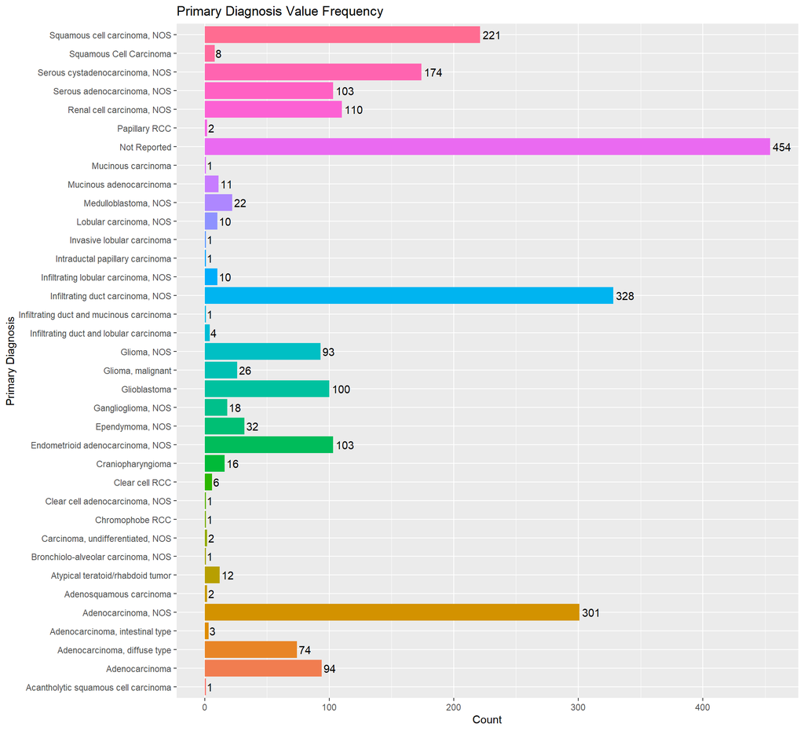

##### Unused Values:

2622 permissible values, 2586 unused values listed below.